# CytoSig cytokine activity

CytoSig：转录组看起来像被哪些细胞因子作用过，不是 ELISA。Lollipop 是样本级 ACI 减去 CTRL。

全细胞 CytoSig ridge，再对中性粒谱系（GMP + Pre-Neut + Neut，与 `08` 一致）做亚型分析。conda **cytosig**。均值热图：每个细胞因子跨细胞 z-score 再取均值。组间 Wilcoxon：细胞级 BH，**样本级原始 p**。Lollipop 样式同 arhgap35 `analysis.R` 的 `ggdotchart`。`group` 以 **CTRL** 为对照。`nrand=0`。

```r
pacman::p_load(
  Seurat, tidyverse, qs2, cowplot, tictoc, reticulate, ggpubr
)
knitr::opts_knit$set(root.dir = "/home/han/Desktop/guoqiang/stroke_bm/stroke_bm_Rproj")
setwd("/home/han/Desktop/guoqiang/stroke_bm/stroke_bm_Rproj")
source("codes/plot_colors.R")
source("codes/activity_helpers.R")
summarise <- dplyr::summarise
mutate <- dplyr::mutate
filter <- dplyr::filter
Sys.setenv(RETICULATE_PYTHON = "/home/han/anaconda3/envs/cytosig/bin/python")
```

```r
res_path <- "results/cytosig"
obj_path <- "data/rdata/activity"
if (dir.exists(res_path)) {
  old_res <- list.files(res_path, full.names = TRUE)
  if (length(old_res) > 0) unlink(old_res, recursive = TRUE)
} else {
  dir.create(res_path, recursive = TRUE)
}
if (!dir.exists(obj_path)) dir.create(obj_path, recursive = TRUE)

nrand <- 0
alpha_ridge <- 1e4
traj_levels <- c(
  "GMP",
  "Promyelocyte", "MMP8 Pre-Neut", "MMP9 Pre-Neut",
  "S100A12 Neut", "SLC8A1 Neut", "ISG15 Neut"
)
```

```r
seurat_object <- qs_read("data/rdata/seurat_object_final.qs2", nthreads = 10)
stopifnot(all(c("sample", "group", "annot_main", "annot_sub") %in%
  colnames(seurat_object[[]])))
seurat_object$group <- factor(seurat_object$group, levels = c("CTRL", "ACI"))
seurat_object$annot_main <- factor(
  as.character(seurat_object$annot_main),
  levels = names(annot_main_col)
)
if (length(Layers(seurat_object, search = "counts")) > 1) {
  seurat_object <- JoinLayers(seurat_object)
}
if (!"data" %in% Layers(seurat_object, search = "data")) {
  seurat_object <- NormalizeData(seurat_object, verbose = TRUE)
}
cell_meta <- FetchData(
  seurat_object,
  vars = c("sample", "group", "annot_main", "annot_sub")
) |>
  rownames_to_column("barcode")
print(table(cell_meta$annot_main, cell_meta$group))
```

```
            CTRL   ACI
  HSPC      1390  1976
  B         3641   664
  Plasma     445   109
  T         6894  3560
  NK         954   793
  Mono/DC   2060  1850
  pDC        363   103
  Pre-Neut  1216 12291
  Neut       885 16783
  Ery       4890   323
```

### 1. CytoSig ridge（全细胞）

给每个细胞打一套细胞因子响应分数。推断「像被什么刺激过」，不是测到的浓度。

用 CytoSig 签名对 log 表达做 ridge，得到每个细胞的细胞因子响应分数。

```r
cs_qs2 <- file.path(obj_path, "cytosig_all.qs2")
if (cache_ok(cs_qs2, colnames(seurat_object))) {
  cs_wide <- qs_read(cs_qs2, nthreads = 10)
} else {
  use_python("/home/han/anaconda3/envs/cytosig/bin/python", required = TRUE)
  pd <- import("pandas", convert = FALSE)
  cs <- import("CytoSig.Util", convert = FALSE)
  sig <- pd$read_csv(py_to_r(cs$find_signature_path()), sep = "\t", index_col = 0L)
  sig_genes <- as.character(py_to_r(sig$index$tolist()))
  expr_genes <- intersect(rownames(seurat_object), sig_genes)
  stopifnot(length(expr_genes) >= 10)
  mat <- as.matrix(
    GetAssayData(seurat_object, assay = "RNA", layer = "data")[expr_genes, ]
  )
  py$expr <- r_to_py(mat)
  py$gene_names <- r_to_py(as.list(rownames(mat)))
  py$cell_names <- r_to_py(as.list(colnames(mat)))
  py$alpha_ridge <- alpha_ridge
  py$nrand <- as.integer(nrand)
  tic("CytoSig ridge_significance_test")
  py_run_string("
import pandas as pd
from CytoSig.Util import ridge_significance_test, find_signature_path
Y = pd.DataFrame(expr, index=list(gene_names), columns=list(cell_names))
sig = pd.read_csv(find_signature_path(), sep='\\t', index_col=0)
res = ridge_significance_test(
    sig, Y,
    alpha=alpha_ridge,
    alternative='two-sided',
    nrand=int(nrand),
    cnt_thres=10,
    flag_normalize=True,
    flag_const=False,
    verbose=True
)
zscore = res[2]
")
  toc()
  z <- py_to_r(py$zscore)
  cs_wide <- as.data.frame(t(as.matrix(z))) |>
    rownames_to_column("barcode")
  qs_save(cs_wide, cs_qs2, nthreads = 10)
}
ck <- features_from_wide(cs_wide)
dat <- bind_meta_acts(cell_meta, cs_wide)
stopifnot(nrow(dat) == nrow(cell_meta))
length(ck)
```

```
[1] 43
```

```r
print(ck)
```

```
 [1] "Activin A" "BDNF"      "BMP2"      "BMP4"      "BMP6"      "CD40L"
 [7] "CXCL12"    "EGF"       "FGF2"      "GCSF"      "GDF11"     "GMCSF"
[13] "HGF"       "IFN1"      "IFNG"      "IFNL"      "IL10"      "IL12"
[19] "IL13"      "IL15"      "IL17A"     "IL1A"      "IL1B"      "IL2"
[25] "IL21"      "IL22"      "IL27"      "IL3"       "IL36"      "IL4"
[31] "IL6"       "LIF"       "LTA"       "MCSF"      "NO"        "OSM"
[37] "TGFB1"     "TGFB3"     "TNFA"      "TRAIL"     "TWEAK"     "VEGFA"
[43] "WNT3A"
```

### 2. 细胞大类：活性热图

哪些大类看起来对哪些细胞因子更敏感。颜色是相对高低。

热图：每个细胞因子先在细胞间 z-score，再按大类取均值。

```r
mean_main <- mean_by_scaled(dat, ck, "annot_main")
p_hm_main <- plot_heatmap_mean(mean_main, ck, row_col = "annot_main") +
  scale_x_discrete(limits = names(annot_main_col))
```

```
heatmap fill
    Min.  1st Qu.   Median     Mean  3rd Qu.     Max.
-1.67646 -0.58416 -0.13992 -0.09939  0.33246  2.15273
|x| q80 / q90 / q95: 0.82 / 1.04 / 1.23
```

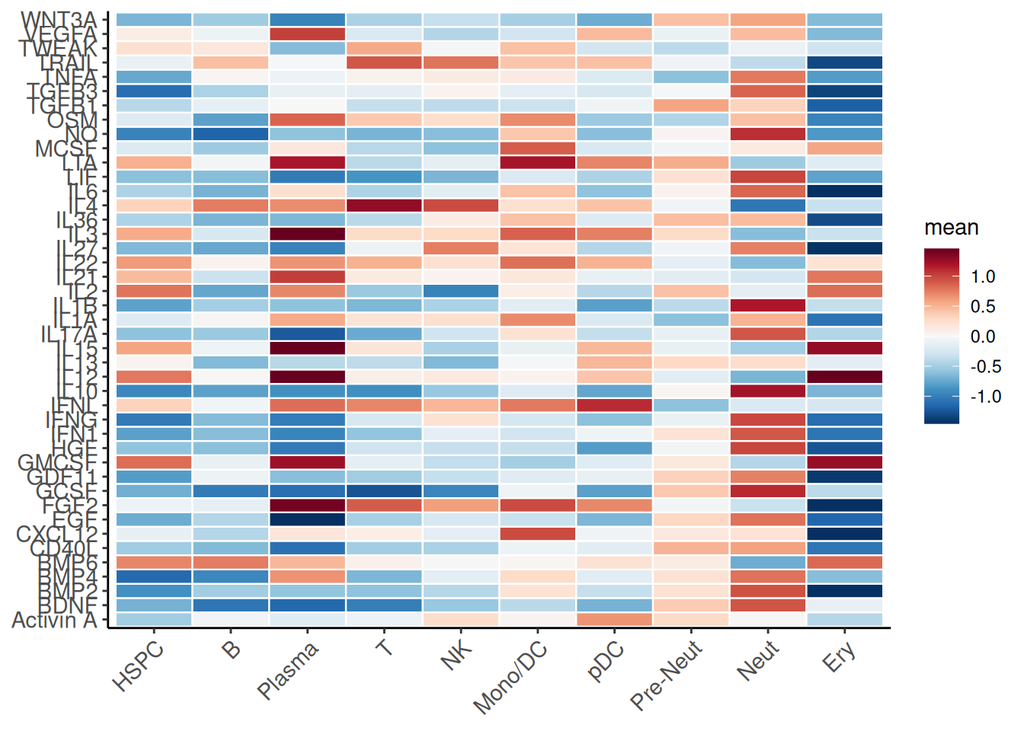

```r
ggsave(file.path(res_path, "01_heatmap_annot_main.pdf"), p_hm_main, width = 8, height = 10, dpi = 600)
p_hm_main
```

```r
mean_main_g <- mean_by_scaled(dat, ck, c("annot_main", "group"))
long_mg <- tidyr::pivot_longer(
  mean_main_g, dplyr::all_of(ck), names_to = "feature", values_to = "mean"
) |>
  dplyr::mutate(
    annot_main = factor(annot_main, levels = names(annot_main_col)),
    group = factor(group, levels = c("CTRL", "ACI"))
  )
p_hm_main_g <- ggplot(long_mg, aes(x = annot_main, y = feature, fill = mean)) +
  geom_tile(color = "white", linewidth = 0.4) +
  facet_wrap(~group, ncol = 2) +
  scale_fill_activity(long_mg$mean) +
  theme_classic() +
  theme(axis.text.x = element_text(angle = 45, hjust = 1, size = 9)) +
  xlab(NULL) +
  ylab(NULL)
```

```
heatmap fill
   Min. 1st Qu.  Median    Mean 3rd Qu.    Max.
-1.9526 -0.5836 -0.1353 -0.1150  0.3159  2.2688
|x| q80 / q90 / q95: 0.888 / 1.11 / 1.29
```

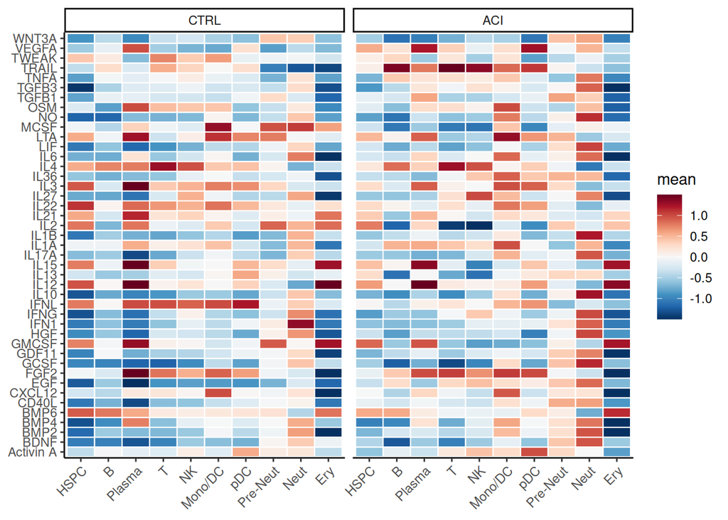

```r
ggsave(file.path(res_path, "01_heatmap_annot_main_group.pdf"), p_hm_main_g, width = 12, height = 10, dpi = 600)
p_hm_main_g
```

### 3. 细胞大类：CTRL vs ACI

各大类上 ACI 减 CTRL。红 = ACI 更高。

```r
ck_cell_main <- add_fdr(cell_group_tests(dat, ck, strata_col = "annot_main")) |>
  dplyr::mutate(annot_main = factor(.data$stratum, levels = names(annot_main_col)))
ck_med_main <- sample_medians(dat, ck, extra_group = "annot_main")
ck_sample_main <- add_stars(sample_group_tests(ck_med_main, ck, strata_col = "annot_main")) |>
  dplyr::mutate(annot_main = factor(.data$stratum, levels = names(annot_main_col)))
write_csv(ck_cell_main, file.path(res_path, "02_wilcox_cell_annot_main.csv"))
write_csv(ck_sample_main, file.path(res_path, "02_wilcox_sample_annot_main.csv"))
print(dplyr::filter(ck_sample_main, .data$p < 0.05))
```

```
# A tibble: 194 × 10
   stratum feature n_sample_ctrl n_sample_aci median_ctrl median_aci
   <chr>   <chr>           <int>        <int>       <dbl>      <dbl>
 1 HSPC    BDNF                6            5      -4.05      -2.76
 2 HSPC    BMP2                6            5      -1.96      -1.15
 3 HSPC    BMP4                6            5      -1.27      -0.900
 4 HSPC    BMP6                6            5       0.728      0.303
 5 HSPC    CD40L               6            5      -0.693      0.625
 6 HSPC    CXCL12              6            5       1.10       1.35
 7 HSPC    EGF                 6            5      -1.01       1.05
 8 HSPC    GCSF                6            5      -1.98       0.142
 9 HSPC    GDF11               6            5      -1.23      -0.788
10 HSPC    HGF                 6            5      -2.55      -1.49
# ℹ 184 more rows
# ℹ 4 more variables: delta_aci_minus_ctrl <dbl>, p <dbl>, star <chr>,
#   annot_main <fct>
```

```r
p_d_s <- ggplot(
  dplyr::mutate(ck_sample_main, feature = factor(feature, levels = ck)),
  aes(x = annot_main, y = feature, fill = delta_aci_minus_ctrl)
) +
  geom_tile(color = "white", linewidth = 0.4) +
  geom_text(aes(label = star), size = 2.2) +
  scale_fill_activity(ck_sample_main$delta_aci_minus_ctrl) +
  theme_classic() +
  theme(axis.text.x = element_text(angle = 45, hjust = 1)) +
  xlab(NULL) +
  ylab(NULL) +
  ggtitle("Sample-level ACI − CTRL (Wilcoxon p)")
```

```
heatmap fill
   Min. 1st Qu.  Median    Mean 3rd Qu.    Max.
-3.4506 -0.3221  0.1258  0.1778  0.6917  3.5940
|x| q80 / q90 / q95: 1.07 / 1.52 / 1.96
```

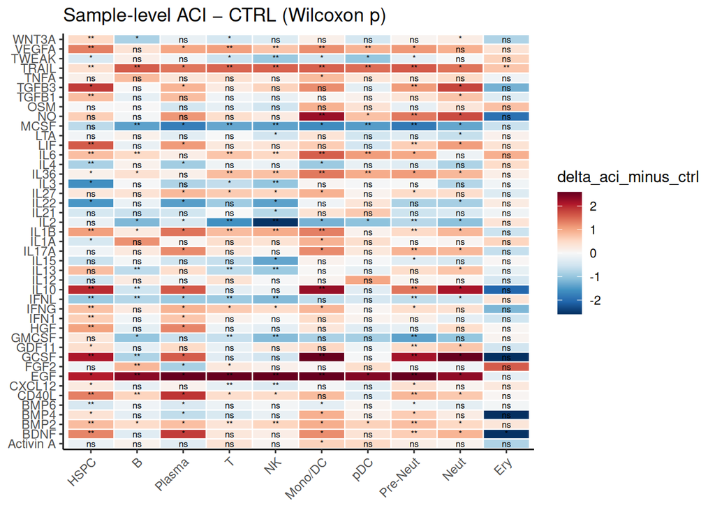

```r
ggsave(file.path(res_path, "02_heatmap_sample_annot_main.pdf"), p_d_s, width = 8, height = 10, dpi = 600)
p_d_s
```

```r
p_d_c <- ggplot(
  dplyr::mutate(ck_cell_main, feature = factor(feature, levels = ck)),
  aes(x = annot_main, y = feature, fill = delta_aci_minus_ctrl)
) +
  geom_tile(color = "white", linewidth = 0.4) +
  geom_text(aes(label = star), size = 2.2) +
  scale_fill_activity(ck_cell_main$delta_aci_minus_ctrl) +
  theme_classic() +
  theme(axis.text.x = element_text(angle = 45, hjust = 1)) +
  xlab(NULL) +
  ylab(NULL) +
  ggtitle("Cell-level ACI − CTRL (BH)")
```

```
heatmap fill
   Min. 1st Qu.  Median    Mean 3rd Qu.    Max.
-2.5838 -0.3561  0.1159  0.1710  0.6928  3.3629
|x| q80 / q90 / q95: 1.04 / 1.48 / 1.92
```

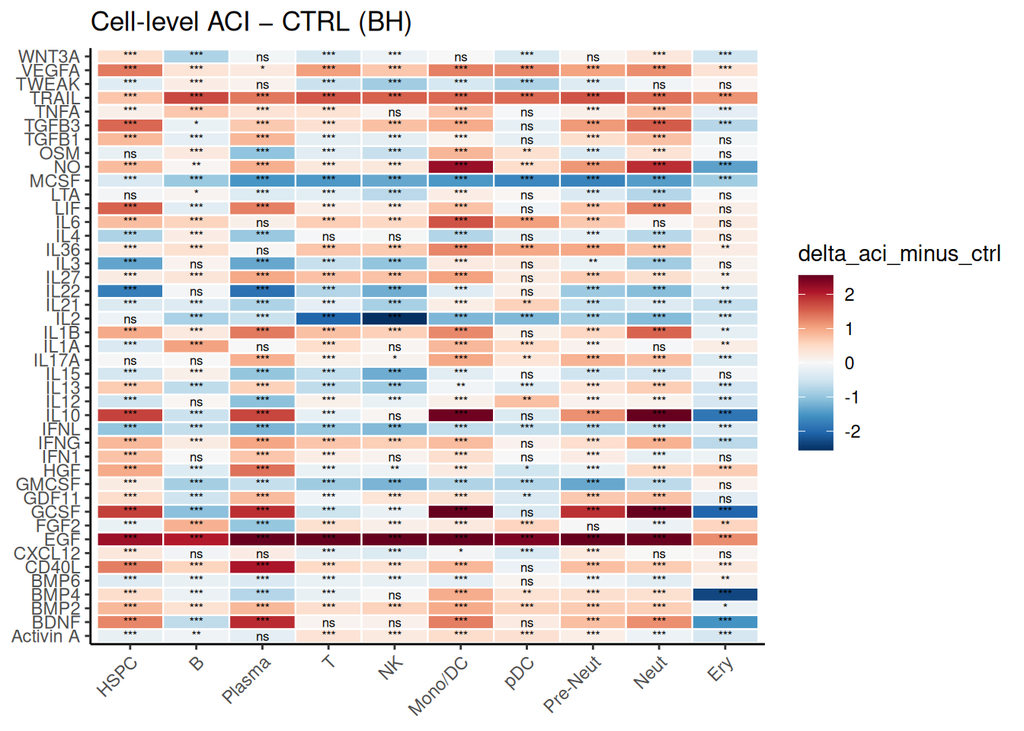

```r
ggsave(file.path(res_path, "02_heatmap_cell_annot_main.pdf"), p_d_c, width = 8, height = 10, dpi = 600)
p_d_c
```

### 4. 中性粒谱系：亚型活性热图

同一套细胞因子在 GMP / Pre-Neut / 成熟粒上的相对高低。

同一套分数，只看 GMP 到成熟粒。

```r
dat_neut <- dat |>
  dplyr::filter(as.character(.data$annot_sub) %in% traj_levels) |>
  dplyr::mutate(
    annot_sub = factor(as.character(.data$annot_sub), levels = traj_levels)
  )
stopifnot(nrow(dat_neut) > 0)
print(table(dat_neut$annot_sub, dat_neut$group))
```

```
                CTRL  ACI
  GMP            204 1320
  Promyelocyte   154 1774
  MMP8 Pre-Neut  294 5696
  MMP9 Pre-Neut  768 4821
  S100A12 Neut   486 7570
  SLC8A1 Neut    280 8465
  ISG15 Neut     119  748
```

```r
mean_sub <- mean_by_scaled(dat_neut, ck, "annot_sub")
p_hm_sub <- plot_heatmap_mean(mean_sub, ck, row_col = "annot_sub") +
  scale_x_discrete(limits = traj_levels)
```

```
heatmap fill
    Min.  1st Qu.   Median     Mean  3rd Qu.     Max.
-2.17251 -0.45296 -0.03157 -0.08672  0.34780  2.81312
|x| q80 / q90 / q95: 0.793 / 1.04 / 1.52
```

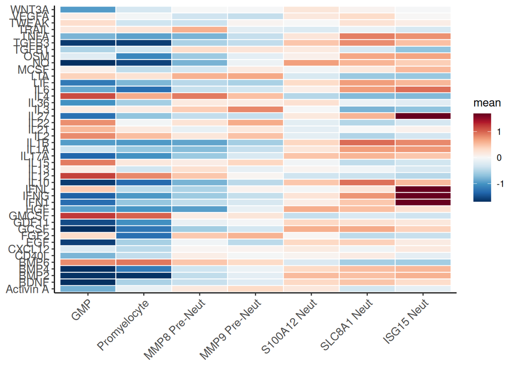

```r
ggsave(file.path(res_path, "03_neut_heatmap_subtype.pdf"), p_hm_sub, width = 8, height = 10, dpi = 600)
p_hm_sub
```

```r
mean_sub_g <- mean_by_scaled(dat_neut, ck, c("annot_sub", "group"))
long_sg <- tidyr::pivot_longer(
  mean_sub_g, dplyr::all_of(ck), names_to = "feature", values_to = "mean"
) |>
  dplyr::mutate(
    annot_sub = factor(annot_sub, levels = traj_levels),
    group = factor(group, levels = c("CTRL", "ACI"))
  )
p_hm_sub_g <- ggplot(long_sg, aes(x = annot_sub, y = feature, fill = mean)) +
  geom_tile(color = "white", linewidth = 0.4) +
  facet_wrap(~group, ncol = 2) +
  scale_fill_activity(long_sg$mean) +
  theme_classic() +
  theme(axis.text.x = element_text(angle = 45, hjust = 1, size = 9)) +
  xlab(NULL) +
  ylab(NULL)
```

```
heatmap fill
   Min. 1st Qu.  Median    Mean 3rd Qu.    Max.
-2.9779 -0.6425 -0.1342 -0.1675  0.3171  3.9001
|x| q80 / q90 / q95: 0.963 / 1.3 / 1.64
```

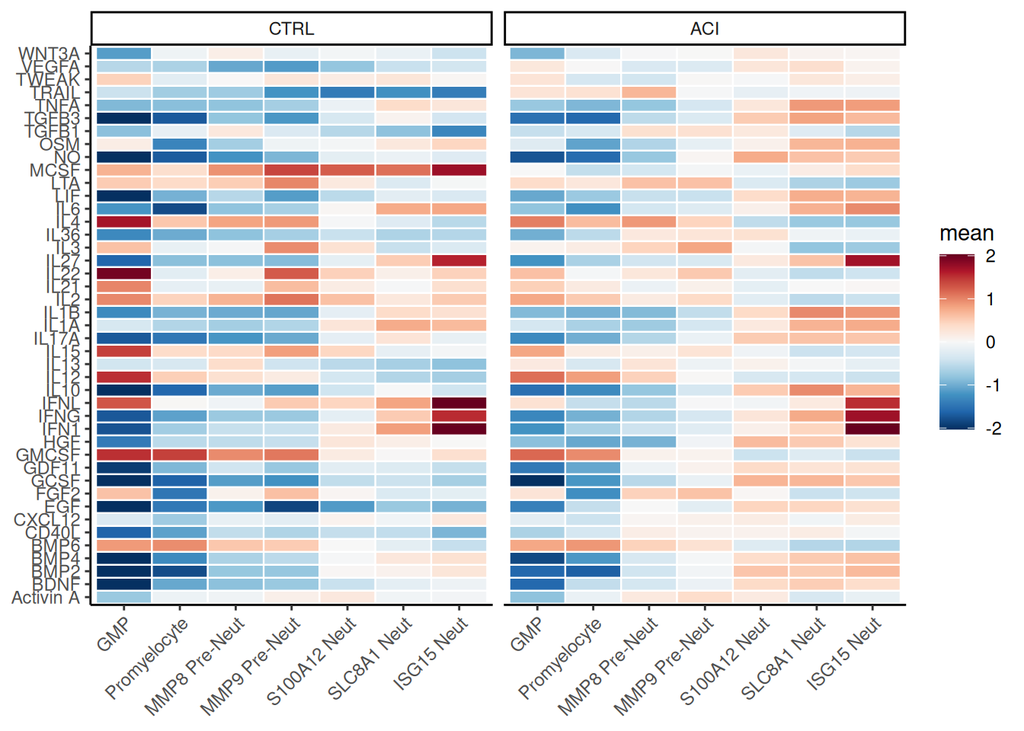

```r
ggsave(file.path(res_path, "03_neut_heatmap_subtype_group.pdf"), p_hm_sub_g, width = 12, height = 10, dpi = 600)
p_hm_sub_g
```

### 5. 中性粒谱系总体：lollipop

中性粒谱系总体：每种细胞因子一个点，高度是样本级 ACI−CTRL。红显著升高，蓝显著降低，灰不显著。

每个点一种细胞因子，高度是样本级 ACI 减 CTRL。先看 IFN 和集落刺激因子落在哪一侧，再对照亚型图看信号停在哪一段。

```r
ck_cell_lineage <- add_fdr(cell_group_tests(dat_neut, ck))
ck_med_lineage <- sample_medians(dat_neut, ck)
ck_sample_lineage <- add_stars(sample_group_tests(ck_med_lineage, ck))
write_csv(ck_cell_lineage, file.path(res_path, "04_neut_wilcox_cell_lineage.csv"))
write_csv(ck_sample_lineage, file.path(res_path, "04_neut_wilcox_sample_lineage.csv"))
print(dplyr::filter(ck_sample_lineage, .data$p < 0.05) |>
  dplyr::arrange(dplyr::desc(delta_aci_minus_ctrl)))
```

```
# A tibble: 29 × 8
   feature n_sample_ctrl n_sample_aci median_ctrl median_aci
   <chr>           <int>        <int>       <dbl>      <dbl>
 1 IL10                6            5      0.408       4.06
 2 GCSF                6            5      2.09        5.58
 3 EGF                 6            5      0.246       3.49
 4 NO                  6            5      2.28        5.23
 5 IL1B                6            5     -0.0511      2.69
 6 TGFB3               6            5      0.175       2.30
 7 IL17A               6            5      1.83        3.38
 8 LIF                 6            5     -0.935       0.551
 9 TRAIL               6            5      1.76        3.14
10 VEGFA               6            5      0.335       1.62
# ℹ 19 more rows
# ℹ 3 more variables: delta_aci_minus_ctrl <dbl>, p <dbl>, star <chr>
```

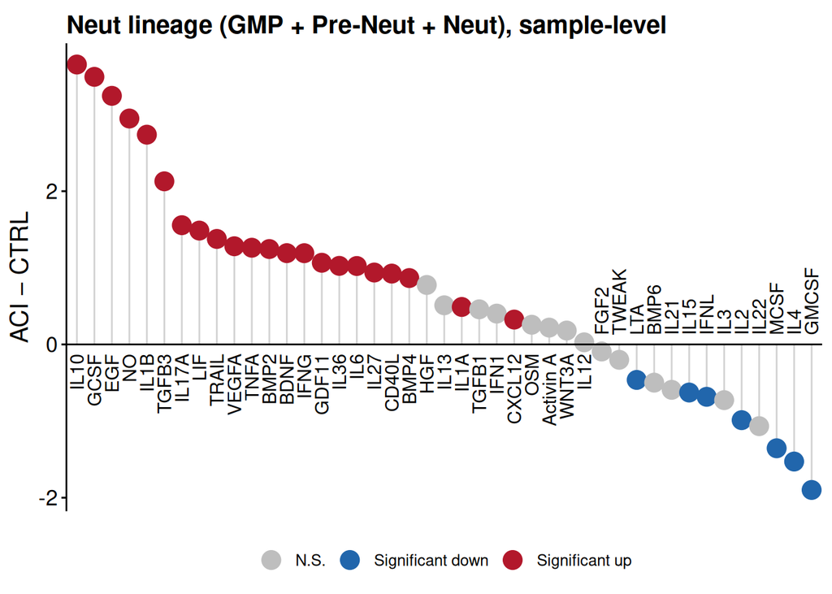

```r
p_lolli_s <- plot_lollipop_delta(
  ck_sample_lineage,
  title = "Neut lineage (GMP + Pre-Neut + Neut), sample-level",
  p_col = "p"
)
ggsave(file.path(res_path, "04_neut_lollipop_sample.pdf"), p_lolli_s, width = 12, height = 4.2, dpi = 600)
p_lolli_s
```

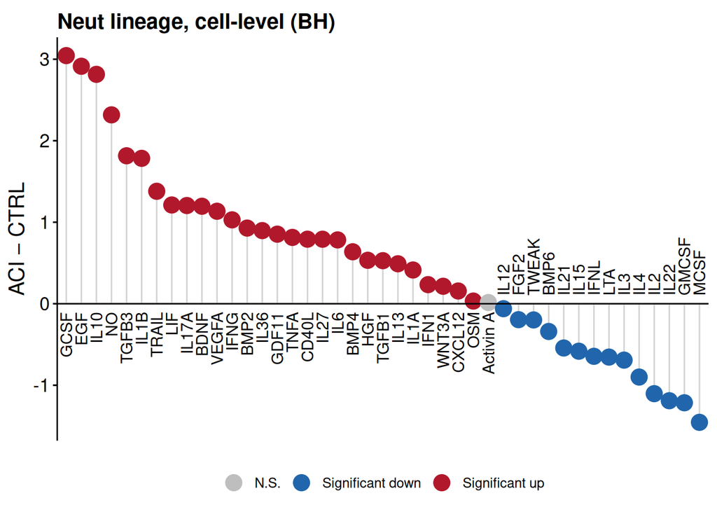

```r
p_lolli_c <- plot_lollipop_delta(
  ck_cell_lineage,
  title = "Neut lineage, cell-level (BH)",
  p_col = "padj"
)
ggsave(file.path(res_path, "04_neut_lollipop_cell.pdf"), p_lolli_c, width = 12, height = 4.2, dpi = 600)
p_lolli_c
```

### 6. 中性粒亚型：CTRL vs ACI

拆到亚型看信号停在哪一段。同样看样本级。

拆到亚型，看信号在前体还是成熟粒。组间仍看每例一个点。

```r
ck_cell_sub <- add_fdr(cell_group_tests(dat_neut, ck, strata_col = "annot_sub")) |>
  dplyr::mutate(annot_sub = factor(.data$stratum, levels = traj_levels))
ck_med_sub <- sample_medians(dat_neut, ck, extra_group = "annot_sub")
ck_sample_sub <- add_stars(sample_group_tests(ck_med_sub, ck, strata_col = "annot_sub")) |>
  dplyr::mutate(annot_sub = factor(.data$stratum, levels = traj_levels))
write_csv(ck_cell_sub, file.path(res_path, "05_neut_wilcox_cell_subtype.csv"))
write_csv(ck_sample_sub, file.path(res_path, "05_neut_wilcox_sample_subtype.csv"))
print(dplyr::filter(ck_sample_sub, .data$p < 0.05))
```

```
# A tibble: 137 × 10
   stratum feature n_sample_ctrl n_sample_aci median_ctrl median_aci
   <chr>   <chr>           <int>        <int>       <dbl>      <dbl>
 1 GMP     BMP2                6            5      -1.69     -0.907
 2 GMP     EGF                 6            5      -1.90      0.661
 3 GMP     HGF                 6            5      -2.15     -1.42
 4 GMP     IFNL                6            5       1.37      0.268
 5 GMP     IL1B                6            5      -0.860     0.0343
 6 GMP     IL36                6            5       1.55      1.91
 7 GMP     IL6                 6            5       1.58      2.35
 8 GMP     NO                  6            5      -0.270     0.224
 9 GMP     TRAIL               6            5       2.34      3.18
10 GMP     VEGFA               6            5       0.845     1.84
# ℹ 127 more rows
# ℹ 4 more variables: delta_aci_minus_ctrl <dbl>, p <dbl>, star <chr>,
#   annot_sub <fct>
```

```r
p_sub_s <- ggplot(
  dplyr::mutate(ck_sample_sub, feature = factor(feature, levels = ck)),
  aes(x = annot_sub, y = feature, fill = delta_aci_minus_ctrl)
) +
  geom_tile(color = "white", linewidth = 0.4) +
  geom_text(aes(label = star), size = 2.2) +
  scale_fill_activity(ck_sample_sub$delta_aci_minus_ctrl) +
  theme_classic() +
  theme(axis.text.x = element_text(angle = 45, hjust = 1)) +
  xlab(NULL) +
  ylab(NULL) +
  ggtitle("Subtype sample-level ACI − CTRL (Wilcoxon p)")
```

```
heatmap fill
   Min. 1st Qu.  Median    Mean 3rd Qu.    Max.
-2.0184 -0.1951  0.3366  0.3400  0.7837  2.9955
|x| q80 / q90 / q95: 1.07 / 1.52 / 1.96
```

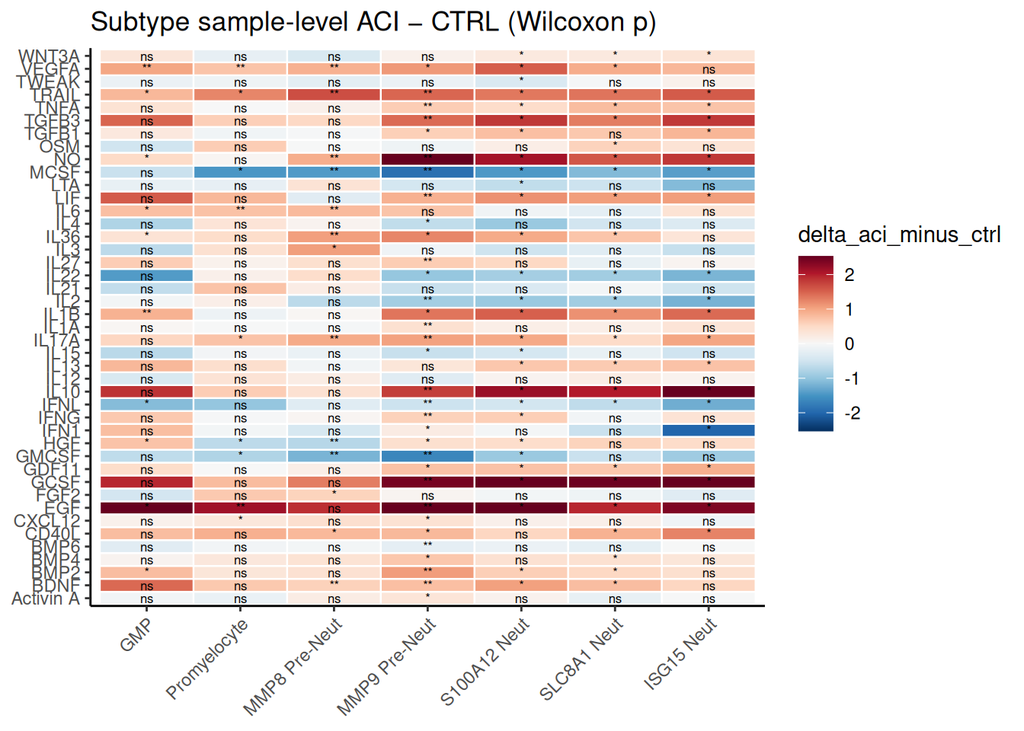

```r
ggsave(file.path(res_path, "05_neut_heatmap_sample_subtype.pdf"), p_sub_s, width = 8, height = 10, dpi = 600)
p_sub_s
```

```r
p_sub_c <- ggplot(
  dplyr::mutate(ck_cell_sub, feature = factor(feature, levels = ck)),
  aes(x = annot_sub, y = feature, fill = delta_aci_minus_ctrl)
) +
  geom_tile(color = "white", linewidth = 0.4) +
  geom_text(aes(label = star), size = 2.2) +
  scale_fill_activity(ck_cell_sub$delta_aci_minus_ctrl) +
  theme_classic() +
  theme(axis.text.x = element_text(angle = 45, hjust = 1)) +
  xlab(NULL) +
  ylab(NULL) +
  ggtitle("Subtype cell-level ACI − CTRL (BH)")
```

```
heatmap fill
   Min. 1st Qu.  Median    Mean 3rd Qu.    Max.
-1.9633 -0.2165  0.2766  0.3486  0.7943  3.1434
|x| q80 / q90 / q95: 1.09 / 1.56 / 2.1
```

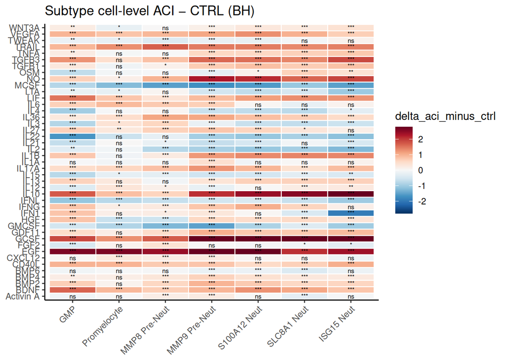

```r
ggsave(file.path(res_path, "05_neut_heatmap_cell_subtype.pdf"), p_sub_c, width = 8, height = 10, dpi = 600)
p_sub_c
```